# Practical Machine Learning Project

Andrés Hidalgo Vargas

31/7/2020

# Background

Six young health participants were asked to perform one set of 10 repetitions of the Unilateral Dumbbell Biceps Curl in five different fashions: exactly according to the specification (Class A), throwing the elbows to the front (Class B), lifting the dumbbell only halfway (Class C), lowering the dumbbell only halfway (Class D) and throwing the hips to the front (Class E). Class A corresponds to the specified execution of the exercise, while the other 4 classes correspond to common mistakes. Participants were supervised by an experienced weight lifter to make sure the execution complied to the manner they were supposed to simulate. The exercises were performed by six male participants aged between 20-28 years, with little weight lifting experience. We made sure that all participants could easily simulate the mistakes in a safe and controlled manner by using a relatively light dumbbell (1.25kg). [Resource](http://groupware.les.inf.puc-rio.br/har)

[Github Repo](https://github.com/AnHiVa/Practical_ML_Project)

# Approach

The goal is to predict the manner in which the individual performed the exercise. Cross validation of decision tree and random forest models will be performed.

# Data preparation

Loading libraries

```r
library(caret); library(tidyverse); library(rpart);
library(rpart.plot); library(rattle); library(corrplot)
```

Download datasets

```r
train_filename <- 'pml-training.csv'
test_filename <- 'pml-testing.csv'

if (!file.exists(train_filename)){

  download.file("https://d396qusza40orc.cloudfront.net/predmachlearn/pml-training.csv",train_filename, method = "curl")
  filedownloadtime <- paste(file.info(train_filename)$ctime, Sys.timezone(), sep = " ")
  print(paste("The Weights training set was downloaded:", filedownloadtime,sep = " "))

} else {

  filedownloadtime <- paste(file.info(train_filename)$ctime, Sys.timezone(), sep = " ")
  print(paste("The Weights training set was downloaded:", filedownloadtime, sep = " "))

}
```

```
## [1] "The Weights training set was downloaded: 2020-07-28 17:37:35 America/Guatemala"
```

```r
if (!file.exists(test_filename)){

  download.file("https://d396qusza40orc.cloudfront.net/predmachlearn/pml-testing.csv",test_filename, method = "curl")
  filedownloadtime <- paste(file.info(test_filename)$ctime, Sys.timezone(), sep = " ")
  print(paste("The Weights testing set was downloaded:", filedownloadtime,sep = " "))

} else {

  filedownloadtime <- paste(file.info(test_filename)$ctime, Sys.timezone(), sep = " ")
  print(paste("The Weights testing set was downloaded:", filedownloadtime, sep = " "))

}
```

```
## [1] "The Weights testing set was downloaded: 2020-07-28 17:35:55 America/Guatemala"
```

Load data

```r
testing <- read_csv('pml-testing.csv')
training <- read_csv('pml-training.csv')

glimpse(training)
```

```
## Rows: 19,622
## Columns: 160
## $ X1                       <dbl> 1, 2, 3, 4, 5, 6, 7, 8, 9, 10, 11, 12, 13,...
## $ user_name                <chr> "carlitos", "carlitos", "carlitos", "carli...
## $ raw_timestamp_part_1     <dbl> 1323084231, 1323084231, 1323084231, 132308...
## $ raw_timestamp_part_2     <dbl> 788290, 808298, 820366, 120339, 196328, 30...
## $ cvtd_timestamp           <chr> "05/12/2011 11:23", "05/12/2011 11:23", "0...
## $ new_window               <chr> "no", "no", "no", "no", "no", "no", "no", ...
## $ num_window               <dbl> 11, 11, 11, 12, 12, 12, 12, 12, 12, 12, 12...
## $ roll_belt                <dbl> 1.41, 1.41, 1.42, 1.48, 1.48, 1.45, 1.42, ...
## $ pitch_belt               <dbl> 8.07, 8.07, 8.07, 8.05, 8.07, 8.06, 8.09, ...
## $ yaw_belt                 <dbl> -94.4, -94.4, -94.4, -94.4, -94.4, -94.4, ...
## $ total_accel_belt         <dbl> 3, 3, 3, 3, 3, 3, 3, 3, 3, 3, 3, 3, 3, 3, ...
## $ kurtosis_roll_belt       <chr> NA, NA, NA, NA, NA, NA, NA, NA, NA, NA, NA...
## $ kurtosis_picth_belt      <chr> NA, NA, NA, NA, NA, NA, NA, NA, NA, NA, NA...
```

[output cut: 147 more lines]

There are a lot of NA in several variables, also, we will only be using variables in the classification of

- Classe
- Gyroscope
- Accelerometer

Clean data

```r
# Lots of summary statistics with almost all NA
training_small <- training %>%
  select(-matches('var|kurtosis|skewness|max|min|amplitude|avg|stddev')) %>%
  mutate(classe = as.factor(classe)) %>%
  group_by(classe)

#Due to the specifications in the article, we will use the gyroscope and accelerometer as our predictor
training_ga <- training_small %>%
  select(matches('classe|^gyros|^accel'))
```

Cut the training set into training and test sets

```r
set.seed(1579)
trainingset <- createDataPartition(y = training_ga$classe, p = 0.6, list = FALSE)
TrainTrainingSet <- training_ga[trainingset, ]
TestTrainingSet <- training_ga[-trainingset, ]
```

## Correlation diagram

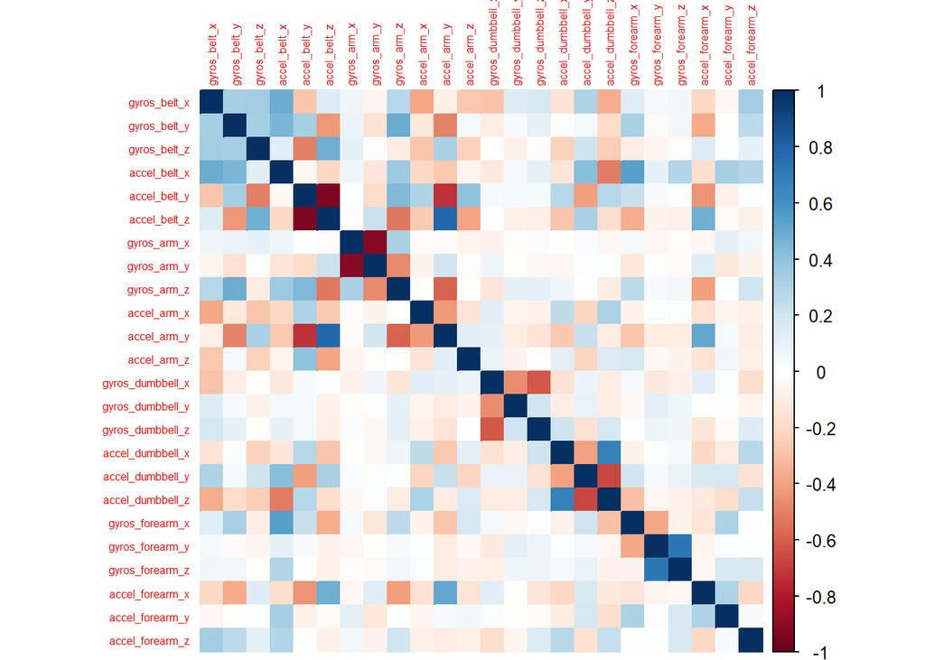

```r
corrplot(cor(TrainTrainingSet[, -length(names(TrainTrainingSet))]),
         method = "color", tl.cex = 0.5)
```

# Decision Tree

```r
set.seed(8745)

model_dt <- rpart(classe~., data= TrainTrainingSet, method = 'class')
pred_dt <- predict(model_dt, TestTrainingSet, type = 'class')
```

Decision tree plot

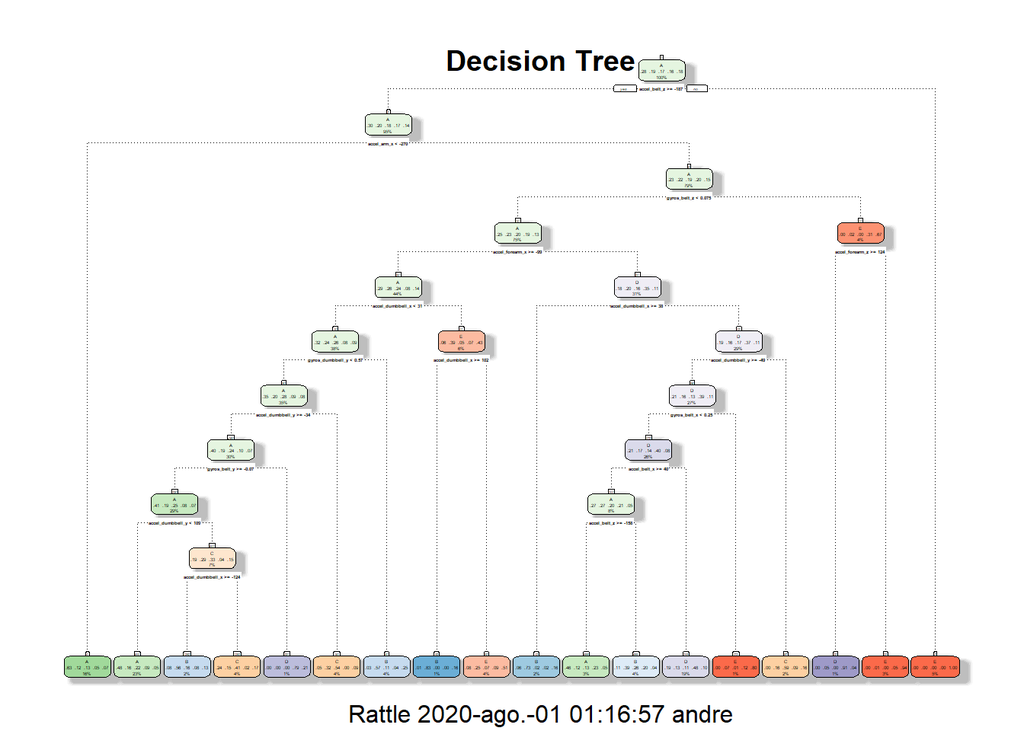

```r
fancyRpartPlot(model_dt, main = 'Decision Tree')
```

Confusion Matrix

```r
confusionMatrix(pred_dt, TestTrainingSet$classe)
```

```
## Confusion Matrix and Statistics
##
##           Reference
## Prediction    A    B    C    D    E
##          A 1728  477  579  291  183
##          B   72  592  139   85  143
##          C   95  184  461   28  114
##          D  300  191  160  831  146
##          E   37   74   29   51  856
##
## Overall Statistics
##
##                Accuracy : 0.5695
##                  95% CI : (0.5584, 0.5805)
##     No Information Rate : 0.2845
##     P-Value [Acc > NIR] : < 2.2e-16
##
##                   Kappa : 0.4468
##
##  Mcnemar's Test P-Value : < 2.2e-16
##
## Statistics by Class:
##
##                      Class: A Class: B Class: C Class: D Class: E
## Sensitivity            0.7742  0.38999  0.33699   0.6462   0.5936
## Specificity            0.7275  0.93063  0.93501   0.8785   0.9702
## Pos Pred Value         0.5304  0.57420  0.52268   0.5104   0.8176
## Neg Pred Value         0.8901  0.86412  0.86976   0.9268   0.9138
## Prevalence             0.2845  0.19347  0.17436   0.1639   0.1838
## Detection Rate         0.2202  0.07545  0.05876   0.1059   0.1091
## Detection Prevalence   0.4152  0.13140  0.11241   0.2075   0.1334
## Balanced Accuracy      0.7508  0.66031  0.63600   0.7623   0.7819
```

The decision tree’s accuracy is 56.95%, which is relatively low for a reliable prediction model.

# Random Forest

```r
set.seed(7654)

model_rf <- train(classe~.,data=TrainTrainingSet, method='rf')
pred_rf <- predict(model_rf, TestTrainingSet)
```

Confusion Matrix

```r
confusionMatrix(pred_rf, TestTrainingSet$classe)
```

```
## Confusion Matrix and Statistics
##
##           Reference
## Prediction    A    B    C    D    E
##          A 2210   31    2    9    0
##          B    4 1465   13    5    0
##          C    2   14 1347   39   12
##          D   16    5    6 1231    4
##          E    0    3    0    2 1426
##
## Overall Statistics
##
##                Accuracy : 0.9787
##                  95% CI : (0.9753, 0.9818)
##     No Information Rate : 0.2845
##     P-Value [Acc > NIR] : < 2.2e-16
##
##                   Kappa : 0.9731
##
##  Mcnemar's Test P-Value : NA
##
## Statistics by Class:
##
##                      Class: A Class: B Class: C Class: D Class: E
## Sensitivity            0.9901   0.9651   0.9846   0.9572   0.9889
## Specificity            0.9925   0.9965   0.9897   0.9953   0.9992
## Pos Pred Value         0.9813   0.9852   0.9526   0.9754   0.9965
## Neg Pred Value         0.9961   0.9917   0.9967   0.9916   0.9975
## Prevalence             0.2845   0.1935   0.1744   0.1639   0.1838
## Detection Rate         0.2817   0.1867   0.1717   0.1569   0.1817
## Detection Prevalence   0.2870   0.1895   0.1802   0.1608   0.1824
## Balanced Accuracy      0.9913   0.9808   0.9872   0.9763   0.9941
```

The random forest model’s accuracy is 97.87%, which is a high accuracy.

# Asignment Answers

Based on the results, the Random Forest algorithm had a better outcome than Decision Trees. The Random Forest accuracy was 97.87% (0.9753, 0.9818) with a 95% confidence level. While the Decision Tree model has an accuracy of 56.95% (0.5584, 0.5805) with a 95% confidence level. Therefore, the Random Forest model is selected to perform the prediction for the assignment test set. With an expected out of sample error of 2.13%.

```r
predict(model_rf, testing)
```

```
##  [1] B A C A A E D B A A B C B A E E A B B B
## Levels: A B C D E
```